# Lecture 15: Multivariate Longitudinal Multilevel Models

Bayesian Psychometric Modeling

```r
# Install/Load Packages ===============================================================================================

if (!require(ggplot2)) install.packages("ggplot2")
library(ggplot2)

if (!require(R2jags)) install.packages("R2jags")
```

```
## Linked to JAGS 4.3.0
```

```
## Loaded modules: basemod,bugs
```

```r
library(R2jags)

if (!require(mcmcplots)) install.packages("mcmcplots")
library(mcmcplots)
```

Today’s data and lecture inspiration come from Lesa Hoffman (http://www.lesahoffman.com) and her book Longitudinal Analysis: Modeling Within-Person Fluctuation and Change (http://www.pilesofvariance.com/). We will be examining data from Chapter 9: Time-Varying Predictors in Models of Change.

```r
Ch9Data = read.csv(file = "Chapter9.csv", header = TRUE)

# check out variable names
names(Ch9Data)
```

```
## [1] "PersonID" "occasion" "risky"    "age18"    "att4"     "mon3"
## [7] "agesq"
```

```r
# check for missing data
apply(X = Ch9Data, MARGIN = 2, FUN = function(x) return(length(which(is.na(x)))))
```

```
## PersonID occasion    risky    age18     att4     mon3    agesq
##        0        0        0        0        0        0        0
```

From Lesa’s Chapter 9 Handout:

> These simulated data are from Hoffman (2015) chapter 9, and include 200 girls measured approximately annually from ages 12–18 (time 0 = age 18) on their risky behavior (the outcome, a sum ranging from 10 to 50) and the extent to which their mothers monitored their activities (the time-varying predictor, a mean ranging from 1 to 5, centered at 3). A time-invariant predictor of the conservativeness of mothers’ attitudes about the smoking and drinking (a mean ranging from 1 to 5, centered at 4) was also collected at the age 12 occasion. Here are the individual growth trajectories for risky behavior and monitoring:

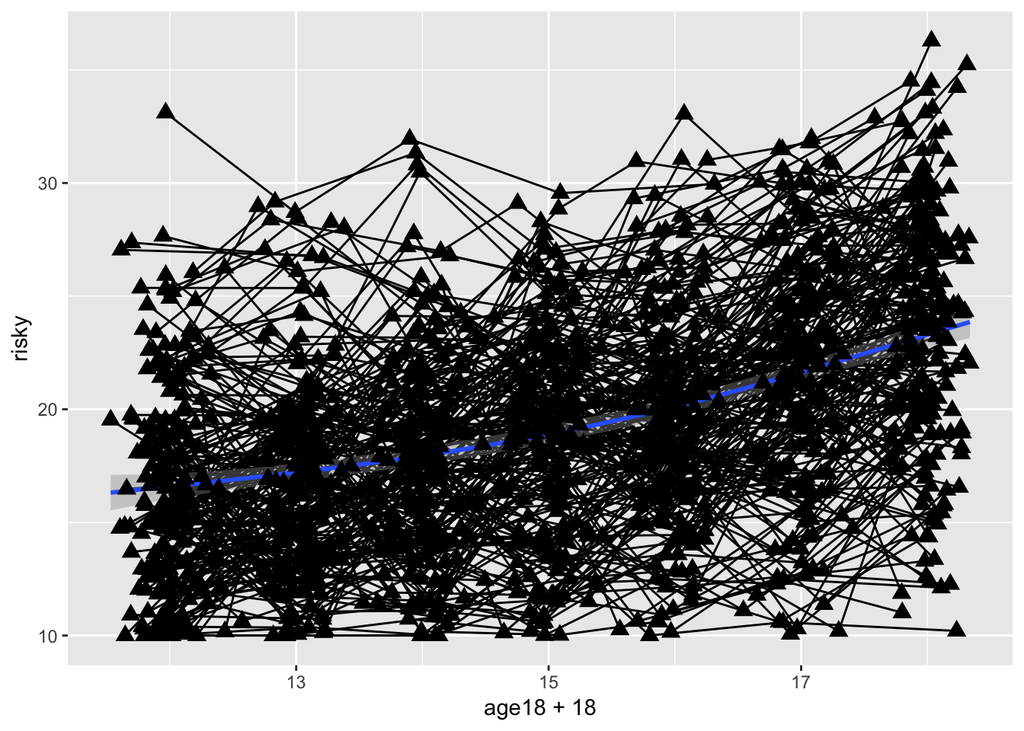

```r
plot1 = ggplot(data = Ch9Data, aes(x = age18+18, y = risky, group = PersonID))

## simple spaghetti plot
plot1 + geom_line() + stat_smooth(aes(group = 1)) + stat_summary(aes(group = 1),
    geom = "point", fun.y = mean, shape = 17, size = 3)
```

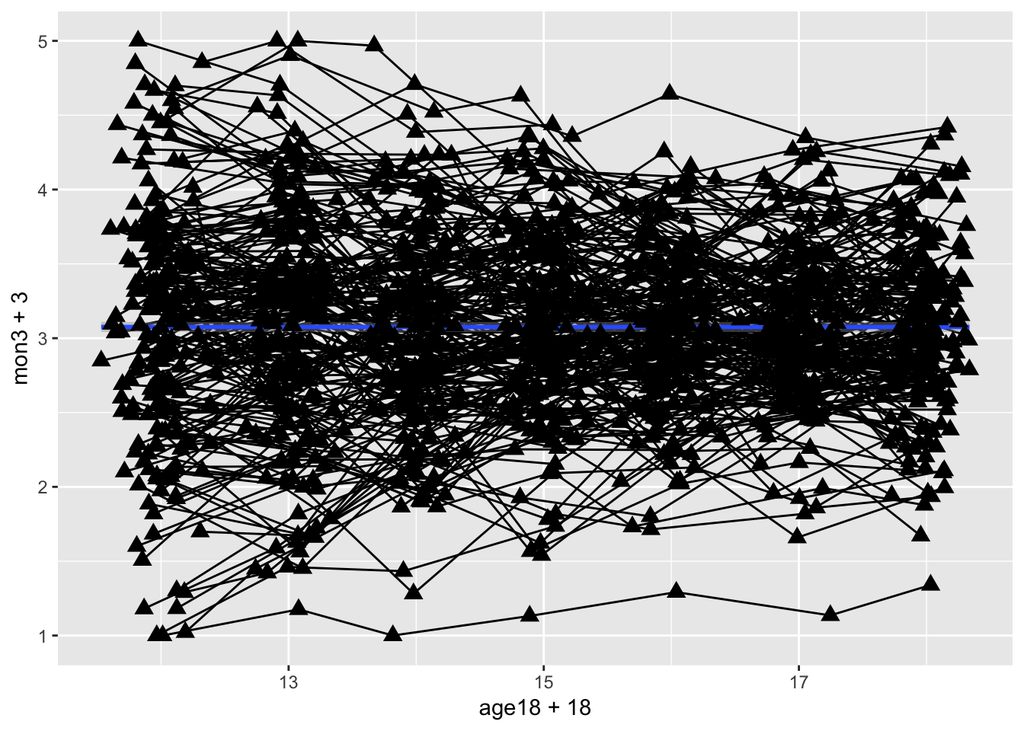

```r
plot2 = ggplot(data = Ch9Data, aes(x = age18+18, y = mon3+3, group = PersonID))

## simple spaghetti plot
plot2 + geom_line() + stat_smooth(aes(group = 1)) + stat_summary(aes(group = 1),
    geom = "point", fun.y = mean, shape = 17, size = 3)
```

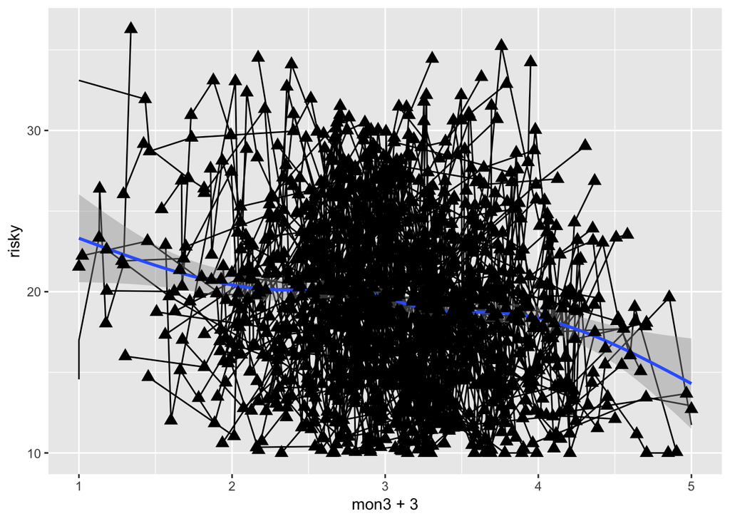

```r
plot3 = ggplot(data = Ch9Data, aes(x = mon3+3, y = risky, group = PersonID))

## simple spaghetti plot
plot3 + geom_line() + stat_smooth(aes(group = 1)) + stat_summary(aes(group = 1),
    geom = "point", fun.y = mean, shape = 17, size = 3)
```

From p.1 of Lesa’s handout (pulled 28 April, 2019)

> The best-fitting unconditional longitudinal models included fixed quadratic and random linear effects of age for risky behavior, but a random linear effect of age for monitoring (although the fixed linear age slope was nonsignificant). In addition, mother’s attitudes significantly predicted the intercept and linear age slope for risky behavior, but did not significantly predict monitoring.

> Chapter 9 began with person-mean-centering and baseline-centering of monitoring of a time-varying predictor of risky behavior. Both were shown to be inadequate because they do not properly distinguish the intercept, linear age slope, and residual variance contained in the monitoring predictor, each of which could potentially relate to those of risky behavior. So the purpose of this example is to demonstrate alternative software methods of estimating models of multivariate change so that you can decide what approach (software and syntax combination) will be most optimal for your own data.

## Model 1: Undirected Multivariate Longitudinal Model

We will adapt Lesa’s multilevel notation as we have a multivariate multilevel model. Most of the notation will remain the same, but the left-hand side of the Level 1 equation chagnes:

##### Level 1

$Monitor_{ti} = \beta_{0iM} +\beta_{1iM}\left(Age_{ti} -18\right) + e_{tiM}$

$Risky_{ti} = \beta_{0iR} +\beta_{1iR}\left(Age_{ti} -18\right) +\beta_{2iR}\left(Age_{ti} -18\right)^2 + e_{tiR}$

##### Level 2 (Monitor):

$\beta_{0iM} = \gamma_{00M} + U_{0iM}$

$\beta_{1iM} = \gamma_{10M} + U_{1iM}$

##### Level 2 (Risky):

$\beta_{0iR} = \gamma_{00R} + \gamma_{01R}\left(Attitudes12_i -4 \right) + U_{0iR}$

$\beta_{1iR} = \gamma_{10R} + \gamma_{11R}\left(Attitudes12_i -4 \right) + U_{1iR}$

$\beta_{2iR} = \gamma_{20R}$

Additionally:

$$\left[ e_{tiR}, e_{tiM}\right]^T \sim MVN\left( \boldsymbol{0}, \boldsymbol{R}\right),$$

where all unique elements of $\boldsymbol{R}$ are estimated (SAS’ TYPE=UN structure), and:

$$\left[ U_{0iM}, U_{0iR}, U_{1iM}, U_{1iR} \right]^T \sim MVN\left( \boldsymbol{0}, \boldsymbol{G}\right),$$
where all unique elements of $\boldsymbol{G}$ are estimated (SAS’ TYPE=UN structure).

We will need to create the two composite models for the dependent variables so as to code these into JAGS:

##### Composite Model for Monitor

$Monitor_{ti} = \left( \gamma_{00M} + U_{0iM}\right) + \left( \gamma_{10M} + U_{1iM}\right)\left(Age_{ti} -18\right) + e_{tiM}$

##### Composite Model for Risky

$Risky_{ti} = \left( \gamma_{00R} + \gamma_{01R}\left(Attitudes12_i -4 \right) + U_{0iR} \right) + \left( \beta_{1iR} = \gamma_{10R} + \gamma_{11R}\left(Attitudes12_i -4 \right) + U_{1iR} \right)\left(Age_{ti} -18\right) + \left( \gamma_{20R}\right)\left(Age_{ti} -18\right)^2 + e_{tiR}$

Next, we need to create terms that JAGS will use to loop over during the data likelihood. Specifically, the number of level-2 observations (`N`), the number of level-1 observations for each level-2 observation (`PersonObs`), and the rows of the original data each level-1 observation within each level-2 observation occupies (`ObsRow`). We will also put both DVs into a single matrix (`X`).

```r
# need total number level-2 observations
N = length(table(Ch9Data$PersonID))

# need number of level-1 observations per level-2 observation
PersonObs = unlist(lapply(X = 1:N, FUN = function(x) return(length(which(Ch9Data$PersonID == x)))))

# format data for import into JAGS: need index for which rows of data belong to which time[person]
ObsRow = sapply(X = 1:N, FUN = function(x) return(which(Ch9Data$PersonID == x)), simplify = TRUE)

# create data matrix
X = cbind(Ch9Data$risky, Ch9Data$mon3)
```

Here, we will use very uninformative priors for all model parameters:

```r
# create prior values for Wishart distributions for G and R
R0  = diag(2)
Rdf = 2

G0  = diag(4)
Gdf = 4

model01.function = function(){

  for (person in 1:N){
    for (time in 1:PersonObs[person]){

      # model for Risky
      meanVec[ObsRow[time, person],1] <-
        (gamma00.risky + gamma01.risky*att4[ObsRow[time, person]] + U[person,1]) +                             # Risky Intercept
        (gamma10.risky + gamma11.risky*att4[ObsRow[time, person]] + U[person,3])*age18[ObsRow[time, person]] + # Risky Linear Age Slope
        (gamma20.risky)*age18[ObsRow[time, person]]^2                                                          # Risky Quadratic Age Slope

      # model for Monitor
      meanVec[ObsRow[time, person],2] <-
        (gamma00.monitor + U[person, 2]) +                                                                    # Monitor Intercept
        (gamma10.monitor + U[person, 4])*age18[ObsRow[time, person]]                                          # Monitor Linear Age Slope

      X[ObsRow[time,person], 1:2] ~ dmnorm(meanVec[ObsRow[time,person], 1:2], R.inv[1:2, 1:2])
    }

  }
  # prior distribution for random effects
  for (person in 1:N){
    U[person, 1:4] ~ dmnorm(meanU[1:4], G.inv[1:4,1:4])
  }

  # hyper priors for U
  for (i in 1:4){
    meanU[i] <- 0 # zero mean
  }

  G.inv[1:4, 1:4] ~ dwish(G0[1:4, 1:4], Gdf)
  R.inv[1:2, 1:2] ~ dwish(R0[1:2, 1:2], Rdf)

  G[1:4, 1:4] <- inverse(G.inv[1:4, 1:4])
  R[1:2, 1:2] <- inverse(R.inv[1:2, 1:2])

  gamma00.risky   ~ dnorm(0, 0.0001)
  gamma01.risky   ~ dnorm(0, 0.0001)
  gamma10.risky   ~ dnorm(0, 0.0001)
  gamma11.risky   ~ dnorm(0, 0.0001)
  gamma20.risky   ~ dnorm(0, 0.0001)
  gamma00.monitor ~ dnorm(0, 0.0001)
  gamma10.monitor ~ dnorm(0, 0.0001)
}

model01.data = list(
  N = N,
  X = X,
  PersonObs = PersonObs,
  ObsRow = ObsRow,
  R0 = R0,
  Rdf = Rdf,
  G0 = G0,
  Gdf = Gdf,
  att4 = Ch9Data$att4,
  age18 = Ch9Data$age18
)

model01.parameters = c("G", "R", "gamma00.risky", "gamma01.risky", "gamma10.risky", "gamma11.risky",
                       "gamma20.risky", "gamma00.monitor", "gamma10.monitor")

model01.seed = 27042019

model01.r2jags =  jags.parallel(
  data = model01.data,
  parameters.to.save = model01.parameters,
  model.file = model01.function,
  n.chains = 4,
  n.iter = 15000,
  n.thin = 1,
  n.burnin = 3000,
  jags.seed = model01.seed
)

model01.r2jags
```

```
## Inference for Bugs model at "model01.function", fit using jags,
##  4 chains, each with 15000 iterations (first 3000 discarded)
##  n.sims = 48000 iterations saved
##                  mu.vect sd.vect     2.5%      25%      50%      75%
## G[1,1]            18.106   2.458   14.073   16.582   18.022   19.561
## G[2,1]            -0.850   0.178   -1.208   -0.964   -0.845   -0.731
## G[3,1]             1.878   0.383    1.222    1.630    1.861    2.115
## G[4,1]             0.054   0.046   -0.035    0.022    0.053    0.085
## G[1,2]            -0.850   0.178   -1.208   -0.964   -0.845   -0.731
## G[2,2]             0.205   0.025    0.162    0.188    0.203    0.220
## G[3,2]            -0.102   0.033   -0.168   -0.123   -0.102   -0.081
## G[4,2]             0.003   0.005   -0.007   -0.001    0.003    0.006
## G[1,3]             1.878   0.383    1.222    1.630    1.861    2.115
## G[2,3]            -0.102   0.033   -0.168   -0.123   -0.102   -0.081
## G[3,3]             0.499   0.082    0.354    0.442    0.494    0.550
## G[4,3]            -0.012   0.008   -0.028   -0.017   -0.012   -0.007
## G[1,4]             0.054   0.046   -0.035    0.022    0.053    0.085
## G[2,4]             0.003   0.005   -0.007   -0.001    0.003    0.006
## G[3,4]            -0.012   0.008   -0.028   -0.017   -0.012   -0.007
## G[4,4]             0.018   0.002    0.014    0.016    0.017    0.019
## R[1,1]             8.425   3.734    7.669    8.114    8.361    8.621
## R[2,1]             0.284   0.030    0.231    0.265    0.283    0.302
## R[1,2]             0.284   0.030    0.231    0.265    0.283    0.302
## R[2,2]             0.081   0.005    0.074    0.079    0.081    0.083
## gamma00.monitor    0.065   0.035   -0.003    0.042    0.065    0.088
## gamma00.risky     23.316   0.349   22.623   23.081   23.317   23.553
## gamma01.risky     -3.322   0.515   -4.327   -3.672   -3.321   -2.977
## gamma10.monitor   -0.003   0.010   -0.023   -0.010   -0.003    0.003
## gamma10.risky      1.974   0.140    1.702    1.880    1.974    2.069
## gamma11.risky     -0.530   0.104   -0.734   -0.600   -0.530   -0.461
## gamma20.risky      0.147   0.021    0.106    0.133    0.147    0.160
## deviance        7214.820  89.305 7121.605 7180.048 7211.142 7243.013
##                    97.5%  Rhat n.eff
## G[1,1]            22.958 1.004 19000
## G[2,1]            -0.521 1.001  8600
## G[3,1]             2.650 1.001 11000
## G[4,1]             0.147 1.001 48000
## G[1,2]            -0.521 1.001  8600
## G[2,2]             0.257 1.001 18000
## G[3,2]            -0.041 1.001  5100
```

[output cut: 13 more lines]

```
## gamma00.monitor    0.134 1.001 29000
## gamma00.risky     23.992 1.001 48000
## gamma01.risky     -2.305 1.001 27000
## gamma10.monitor    0.016 1.001 41000
## gamma10.risky      2.249 1.001 48000
## gamma11.risky     -0.327 1.001 48000
## gamma20.risky      0.187 1.001 48000
## deviance        7308.964 1.001 43000
##
## For each parameter, n.eff is a crude measure of effective sample size,
## and Rhat is the potential scale reduction factor (at convergence, Rhat=1).
##
## DIC info (using the rule, pD = var(deviance)/2)
## pD = 3987.7 and DIC = 11202.5
## DIC is an estimate of expected predictive error (lower deviance is better).
```

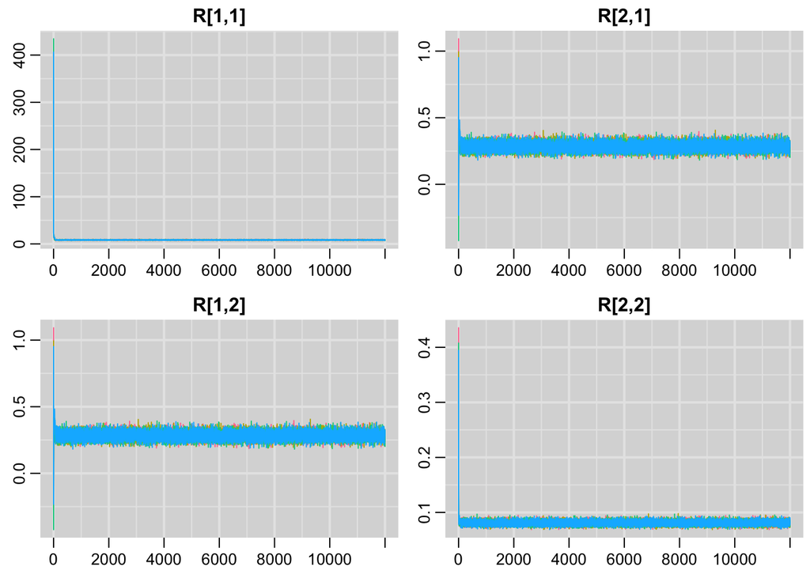

```r
traplot(model01.r2jags, parms = "R")
```

```r
# R2jags is acting strange with n.burnin...and upon inspection, it is using burnin to adapt the algorithm.

model01a = window(x = as.mcmc(model01.r2jags), start = 2001, end = 12000)

model01a.results = cbind(round(summary(model01a)$statistics, 4), round(summary(model01a)$quantiles, 4), gelman.diag(model01a, multivariate = FALSE)[[1]][,1])
model01a.results
```

```
##                      Mean      SD Naive SE Time-series SE      2.5%
## G[1,1]            18.1719  2.2380   0.0112         0.0167   14.2135
## G[2,1]            -0.8528  0.1743   0.0009         0.0012   -1.2103
## G[3,1]             1.8868  0.3600   0.0018         0.0034    1.2455
## G[4,1]             0.0544  0.0464   0.0002         0.0003   -0.0347
## G[1,2]            -0.8528  0.1743   0.0009         0.0012   -1.2103
## G[2,2]             0.2051  0.0243   0.0001         0.0002    0.1618
## G[3,2]            -0.1030  0.0315   0.0002         0.0003   -0.1678
## G[4,2]             0.0026  0.0049   0.0000         0.0000   -0.0068
## G[1,3]             1.8868  0.3600   0.0018         0.0034    1.2455
## G[2,3]            -0.1030  0.0315   0.0002         0.0003   -0.1678
## G[3,3]             0.4996  0.0807   0.0004         0.0009    0.3569
## G[4,3]            -0.0120  0.0082   0.0000         0.0001   -0.0283
## G[1,4]             0.0544  0.0464   0.0002         0.0003   -0.0347
## G[2,4]             0.0026  0.0049   0.0000         0.0000   -0.0068
## G[3,4]            -0.0120  0.0082   0.0000         0.0001   -0.0283
## G[4,4]             0.0176  0.0019   0.0000         0.0000    0.0142
## R[1,1]             8.3715  0.3759   0.0019         0.0027    7.6700
## R[2,1]             0.2833  0.0274   0.0001         0.0002    0.2310
## R[1,2]             0.2833  0.0274   0.0001         0.0002    0.2310
## R[2,2]             0.0810  0.0036   0.0000         0.0000    0.0743
## deviance        7211.7178 46.7235   0.2336         0.3440 7121.5057
## gamma00.monitor    0.0650  0.0349   0.0002         0.0002   -0.0034
## gamma00.risky     23.3152  0.3492   0.0017         0.0017   22.6232
## gamma01.risky     -3.3219  0.5161   0.0026         0.0026   -4.3325
## gamma10.monitor   -0.0032  0.0101   0.0001         0.0001   -0.0229
## gamma10.risky      1.9741  0.1389   0.0007         0.0007    1.7041
## gamma11.risky     -0.5305  0.1035   0.0005         0.0005   -0.7330
## gamma20.risky      0.1465  0.0206   0.0001         0.0001    0.1061
##                       25%       50%       75%     97.5%
## G[1,1]            16.6022   18.0372   19.5688   22.9584 1.0002641
## G[2,1]            -0.9652   -0.8464   -0.7330   -0.5283 1.0003663
## G[3,1]             1.6343    1.8641    2.1163    2.6511 1.0006850
## G[4,1]             0.0229    0.0533    0.0850    0.1480 1.0000389
## G[1,2]            -0.9652   -0.8464   -0.7330   -0.5283 1.0003663
## G[2,2]             0.1882    0.2035    0.2203    0.2568 1.0001855
## G[3,2]            -0.1234   -0.1023   -0.0817   -0.0431 1.0005679
## G[4,2]            -0.0007    0.0025    0.0057    0.0124 1.0000110
## G[1,3]             1.6343    1.8641    2.1163    2.6511 1.0006850
## G[2,3]            -0.1234   -0.1023   -0.0817   -0.0431 1.0005679
## G[3,3]             0.4430    0.4942    0.5504    0.6733 1.0009767
## G[4,3]            -0.0174   -0.0119   -0.0065    0.0039 1.0000844
## G[1,4]             0.0229    0.0533    0.0850    0.1480 1.0000389
## G[2,4]            -0.0007    0.0025    0.0057    0.0124 1.0000110
## G[3,4]            -0.0174   -0.0119   -0.0065    0.0039 1.0000844
## G[4,4]             0.0162    0.0174    0.0188    0.0218 1.0000543
## R[1,1]             8.1128    8.3583    8.6179    9.1417 1.0003278
## R[2,1]             0.2645    0.2829    0.3013    0.3385 1.0001753
## R[1,2]             0.2645    0.2829    0.3013    0.3385 1.0001753
## R[2,2]             0.0786    0.0810    0.0834    0.0883 0.9999758
## deviance        7180.1458 7211.1345 7242.7208 7305.2909 1.0000744
## gamma00.monitor    0.0417    0.0652    0.0884    0.1336 0.9999978
## gamma00.risky     23.0796   23.3161   23.5520   23.9920 0.9999729
## gamma01.risky     -3.6722   -3.3212   -2.9765   -2.3029 1.0003292
## gamma10.monitor   -0.0101   -0.0032    0.0035    0.0165 0.9999902
## gamma10.risky      1.8798    1.9742    2.0683    2.2482 0.9999971
## gamma11.risky     -0.5995   -0.5303   -0.4613   -0.3265 1.0001748
## gamma20.risky      0.1326    0.1465    0.1604    0.1869 0.9999626
```

Next, we add Monitor to the prediction of Risky, using the entire value of Monitor in the prediction. Note, this corresponds to Mplus’ ML estimator for this model. Again, will adapt Lesa’s multilevel notation as we have a multivariate multilevel model. Most of the notation will remain the same, but the left-hand side of the Level 1 equation chagnes:

##### Level 1

$Monitor_{ti} = \beta_{0iM} +\beta_{1iM}\left(Age_{ti} -18\right) + e_{tiM}$

$Risky_{ti} = \beta_{0iR} +\beta_{1iR}\left(Age_{ti} -18\right) +\beta_{2iR}\left(Age_{ti} -18\right)^2 + \beta_{3iR}\left(Monitor_{ti}\right) e_{tiR}$

##### Level 2 (Monitor):

$\beta_{0iM} = \gamma_{00M} + U_{0iM}$

$\beta_{1iM} = \gamma_{10M} + U_{1iM}$

##### Level 2 (Risky):

$\beta_{0iR} = \gamma_{00R} + \gamma_{01R}\left(Attitudes12_i -4 \right) + \gamma_{02R}\left(\gamma_{00M} + U_{0iM}\right) + \gamma_{03M}\left(\gamma_{10M} + U_{1iM} \right) + U_{0iR}$

$\beta_{1iR} = \gamma_{10R} + \gamma_{11R}\left(Attitudes12_i -4 \right) + \gamma_{12R}\left(\gamma_{00M} + U_{0iM}\right) + \gamma_{13M}\left(\gamma_{10M} + U_{1iM} \right) + U_{1iR}$

$\beta_{2iR} = \gamma_{20R}$

$\beta_{3iR} = \gamma_{30R}$

Now, a few things are different:

$$\left[ e_{tiR}, e_{tiM}\right]^T \sim MVN\left( \boldsymbol{0}, \boldsymbol{R}\right),$$

where all unique diagonal elements of $\boldsymbol{R}$ are estimated and the off-diagonal elements are set to zero (SAS’ TYPE=VC structure), and:

$$\left[ U_{0iM}, U_{1iM}\right]^T \sim MVN\left( \boldsymbol{0}, \boldsymbol{G}_M\right),$$

where all unique elements of $\boldsymbol{G}_M$ are estimated (SAS’ TYPE=UN structure), and

$$\left[ U_{0iR}, U_{1iR} \right]^T \sim MVN\left( \boldsymbol{0}, \boldsymbol{G}_R\right),$$
where all unique elements of $\boldsymbol{G}_R$ are estimated (SAS’ TYPE=UN structure).

We will need to create the two composite models for the dependent variables so as to code these into JAGS:

##### Composite Model for Monitor

$Monitor_{ti} = \left( \gamma_{00M} + U_{0iM}\right) + \left( \gamma_{10M} + U_{1iM}\right)\left(Age_{ti} -18\right) + e_{tiM}$

##### Composite Model for Risky

$Risky_{ti} = \left( \gamma_{00R} + \gamma_{01R}\left(Attitudes12_i -4 \right) + \gamma_{02R}\left(\gamma_{00M} + U_{0iM}\right) + \gamma_{03M}\left(\gamma_{10M} + U_{1iM} \right) + U_{0iR} \right) + \left( \gamma_{10R} + \gamma_{11R}\left(Attitudes12_i -4 \right) + \gamma_{12R}\left(\gamma_{00M} + U_{0iM}\right) + \gamma_{13M}\left(\gamma_{10M} + U_{1iM} \right) + U_{1iR}\right)\left(Age_{ti} -18\right) + \left( \gamma_{20R}\right)\left(Age_{ti} -18\right)^2 + \left( \gamma_{30R} \right)Monitor_{ti} +e_{tiR}$

Here, we will break up the level-1 residuals to estimate with `dnorm()`, which is equivalent to setting the covariance to zero.

```r
# setting priors for variances -- keeping all terms independent as additional model parameters do the same job

# risky R matrix
sigma2.inv.risky.sse0 = .5*var(Ch9Data$risky)
sigma2.inv.risky.df0 = 1

sigma2.inv.risky.alpha0 = sigma2.inv.risky.df0/2
sigma2.inv.risky.beta0 = (sigma2.inv.risky.df0*sigma2.inv.risky.sse0)/2

# risky G matrix
G0risky  = c(.4*var(Ch9Data$risky), .1*var(Ch9Data$risky))*diag(2)
G0risky.df = 2

# monitor R matrix
sigma2.inv.monitor.sse0 = .5*var(Ch9Data$mon3)
sigma2.inv.monitor.df0 = 1

sigma2.inv.monitor.alpha0 = sigma2.inv.monitor.df0/2
sigma2.inv.monitor.beta0 = (sigma2.inv.monitor.df0*sigma2.inv.monitor.sse0)/2

# monitor G matrix
G0monitor = c(.4*var(Ch9Data$mon3), .1*var(Ch9Data$mon3))*diag(2)
G0monitor.df = 2

model02.function = function(){

  for (person in 1:N){
    for (time in 1:PersonObs[person]){

      # model for Risky
      meanVec[ObsRow[time, person],1] <-
        (gamma00.risky + gamma01.risky*att4[ObsRow[time, person]] +                                    # Risky Intercept
           gamma02.risky*(gamma00.monitor + U.monitor[person,1]) +
           gamma03.risky*(gamma10.monitor + U.monitor[person,2]) + U.risky[person,1]) +
        (gamma10.risky + gamma11.risky*att4[ObsRow[time, person]] +                                    # Risky Linear Age Slope
           gamma12.risky*(gamma00.monitor + U.monitor[person,1]) +
           gamma13.risky*(gamma10.monitor + U.monitor[person,2]) +
           U.risky[person,2])*age18[ObsRow[time, person]] +
        (gamma20.risky)*age18[ObsRow[time, person]]^2 +                                                # Risky Quadratic Age Slope
        gamma30.risky*Monitor[ObsRow[time,person]]                                                     # Risky Monitor Slope

      X[ObsRow[time,person], 1] ~ dnorm(meanVec[ObsRow[time,person], 1], sigma2.inv.risky)             # Univariate normal likelihood as R has zero covariance

      # model for Monitor
      meanVec[ObsRow[time, person],2] <-                                                               # Monitor Intercept
        (gamma00.monitor + U.monitor[person, 1]) +
        (gamma10.monitor + U.monitor[person, 2])*age18[ObsRow[time, person]]                                   # Monitor Linear Age Slope

      X[ObsRow[time,person], 2] ~ dnorm(meanVec[ObsRow[time,person], 2], sigma2.inv.monitor)           # Univariate normal likelihood as R has zero covariance
    }

  }

  # prior distributions for R matrix variances
  sigma2.inv.risky       ~ dgamma(sigma2.inv.risky.alpha0,       sigma2.inv.risky.beta0)
  sigma2.inv.monitor     ~ dgamma(sigma2.inv.monitor.alpha0,     sigma2.inv.monitor.beta0)

  sigma2.risky      <- 1/sigma2.inv.risky
  sigma2.monitor    <- 1/sigma2.inv.monitor


  # prior distributions for random effects
  for (person in 1:N){
    U.risky[person, 1:2]   ~ dmnorm(U.risky.mean[1:2],   G.inv.risky[1:2,1:2])
    U.monitor[person, 1:2] ~ dmnorm(U.monitor.mean[1:2], G.inv.monitor[1:2,1:2])
  }

  # prior distributions for random effects G matrices
  G.inv.risky ~ dwish(G0risky, G0risky.df)
  G.risky <- inverse(G.inv.risky)

  G.inv.monitor ~ dwish(G0monitor, G0monitor.df)
  G.monitor <- inverse(G.inv.monitor)

  # prior distributions for fixed effects
  gamma00.risky   ~ dnorm(0, 0.0001)
  gamma01.risky   ~ dnorm(0, 0.0001)
  gamma10.risky   ~ dnorm(0, 0.0001)
  gamma11.risky   ~ dnorm(0, 0.0001)
  gamma20.risky   ~ dnorm(0, 0.0001)
  gamma02.risky   ~ dnorm(0, 0.0001)
  gamma03.risky   ~ dnorm(0, 0.0001)
  gamma12.risky   ~ dnorm(0, 0.0001)
  gamma13.risky   ~ dnorm(0, 0.0001)
  gamma30.risky   ~ dnorm(0, 0.0001)
  gamma00.monitor ~ dnorm(0, 0.0001)
  gamma10.monitor ~ dnorm(0, 0.0001)

}

model02.data = list(
  N = N,
  X = cbind(Ch9Data$risky, Ch9Data$mon3),
  PersonObs = PersonObs,
  ObsRow = ObsRow,
  att4 = Ch9Data$att4,
  age18 = Ch9Data$age18,
  Monitor = Ch9Data$mon3,
  sigma2.inv.risky.alpha0 = sigma2.inv.risky.alpha0,
  sigma2.inv.risky.beta0 = sigma2.inv.risky.beta0,
  sigma2.inv.monitor.alpha0 = sigma2.inv.monitor.alpha0,
  sigma2.inv.monitor.beta0 = sigma2.inv.monitor.beta0,
  G0monitor = G0monitor,
  G0monitor.df = G0monitor.df,
  U.monitor.mean = rep(0,2),
  G0risky = G0risky,
  G0risky.df = G0risky.df,
  U.risky.mean = rep(0,2)
)

model02.parameters = c("gamma00.risky", "gamma01.risky", "gamma10.risky", "gamma11.risky",
                       "gamma20.risky", "gamma00.monitor", "gamma10.monitor", "gamma02.risky",
                       "gamma03.risky", "gamma12.risky", "gamma13.risky", "gamma30.risky",
                       "sigma2.risky", "sigma2.monitor", "G.risky", "G.monitor")

model02.seed = 27042019+1

model02.r2jags =  jags.parallel(
  data = model02.data,
  parameters.to.save = model02.parameters,
  model.file = model02.function,
  n.chains = 4,
  n.iter = 15000,
  n.thin = 1,
  n.burnin = 3000,
  jags.seed = model02.seed
)

model02.r2jags
```

```
## Inference for Bugs model at "model02.function", fit using jags,
##  4 chains, each with 15000 iterations (first 3000 discarded)
##  n.sims = 48000 iterations saved
##                  mu.vect sd.vect     2.5%      25%      50%      75%
## G.monitor[1,1]     0.192   0.035    0.141    0.179    0.194    0.211
## G.monitor[2,1]    -0.001   0.004   -0.009   -0.004   -0.001    0.002
## G.monitor[1,2]    -0.001   0.004   -0.009   -0.004   -0.001    0.002
## G.monitor[2,2]     0.011   0.002    0.008    0.010    0.011    0.012
## G.risky[1,1]      14.326   2.502   10.111   12.977   14.355   15.787
## G.risky[2,1]       1.536   0.393    0.835    1.286    1.524    1.778
## G.risky[1,2]       1.536   0.393    0.835    1.286    1.524    1.778
## G.risky[2,2]       0.454   0.100    0.298    0.391    0.447    0.507
## gamma00.monitor    0.065   0.034   -0.002    0.042    0.065    0.088
## gamma00.risky     23.790   1.579   22.943   23.390   23.622   23.856
## gamma01.risky     -3.328   0.524   -4.348   -3.680   -3.328   -2.975
## gamma02.risky    -10.601  21.938  -10.386   -8.616   -7.988   -7.386
## gamma03.risky      4.552  12.980   -4.087    1.127    3.609    6.047
## gamma10.monitor   -0.003   0.008   -0.020   -0.009   -0.003    0.002
## gamma10.risky      2.003   0.311    1.715    1.908    2.006    2.102
## gamma11.risky     -0.528   0.108   -0.738   -0.600   -0.529   -0.457
## gamma12.risky     -0.521   4.080   -0.943   -0.673   -0.556   -0.441
## gamma13.risky     -5.374   2.557   -7.143   -5.856   -5.264   -4.685
## gamma20.risky      0.147   0.021    0.106    0.133    0.147    0.161
## gamma30.risky      3.542   0.316    2.934    3.336    3.543    3.750
## sigma2.monitor     0.083   0.013    0.074    0.079    0.081    0.084
## sigma2.risky       7.391   3.607    6.740    7.126    7.343    7.570
## deviance        7238.962 154.681 7129.860 7188.454 7220.496 7254.402
##                    97.5%  Rhat n.eff
## G.monitor[1,1]     0.247 1.101   240
## G.monitor[2,1]     0.008 1.003  1300
## G.monitor[1,2]     0.008 1.003  1300
## G.monitor[2,2]     0.014 1.019   560
## G.risky[1,1]      18.889 1.029   550
## G.risky[2,1]       2.327 1.002  2200
## G.risky[1,2]       2.327 1.002  2200
## G.risky[2,2]       0.645 1.004  1500
## gamma00.monitor    0.132 1.001 48000
## gamma00.risky     24.453 1.177   170
## gamma01.risky     -2.299 1.001 32000
## gamma02.risky     -6.249 1.212   150
## gamma03.risky     11.438 1.154   200
## gamma10.monitor    0.013 1.001 32000
## gamma10.risky      2.307 1.086   540
## gamma11.risky     -0.314 1.001 28000
## gamma12.risky     -0.210 1.130   440
## gamma13.risky     -3.495 1.067   520
## gamma20.risky      0.187 1.001 19000
## gamma30.risky      4.154 1.002  1900
## sigma2.monitor     0.092 1.085   290
## sigma2.risky       8.032 1.001 19000
## deviance        7355.551 1.079   290
##
## For each parameter, n.eff is a crude measure of effective sample size,
## and Rhat is the potential scale reduction factor (at convergence, Rhat=1).
##
## DIC info (using the rule, pD = var(deviance)/2)
## pD = 11849.1 and DIC = 19088.0
## DIC is an estimate of expected predictive error (lower deviance is better).
```

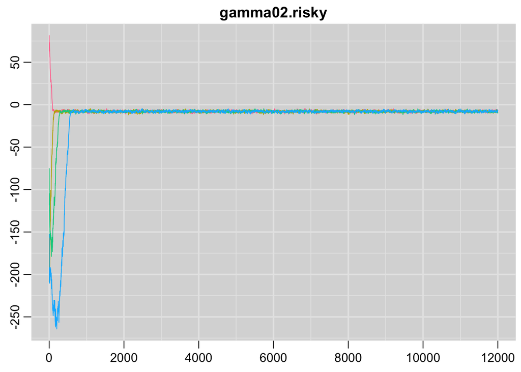

```r
traplot(model02.r2jags, parms = "gamma02.risky")
```

```r
# R2jags is acting strange with n.burnin...and upon inspection, it is using burnin to adapt the algorithm.

model02a = window(x = as.mcmc(model02.r2jags), start = 2001, end = 12000)

model02a.results = cbind(round(summary(model02a)$statistics, 4), round(summary(model02a)$quantiles, 4), gelman.diag(model02a, multivariate = FALSE)[[1]][,1])
model02a.results
```

```
##                      Mean      SD Naive SE Time-series SE      2.5%
## G.monitor[1,1]     0.1964  0.0236   0.0001         0.0002    0.1545
## G.monitor[2,1]    -0.0008  0.0041   0.0000         0.0000   -0.0085
## G.monitor[1,2]    -0.0008  0.0041   0.0000         0.0000   -0.0085
## G.monitor[2,2]     0.0108  0.0014   0.0000         0.0000    0.0083
## G.risky[1,1]      14.5259  2.0513   0.0103         0.0215   10.8670
## G.risky[2,1]       1.5506  0.3597   0.0018         0.0045    0.8982
## G.risky[1,2]       1.5506  0.3597   0.0018         0.0045    0.8982
## G.risky[2,2]       0.4518  0.0845   0.0004         0.0011    0.3020
## deviance        7219.8610 47.2797   0.2364         0.3745 7129.0570
## gamma00.monitor    0.0650  0.0342   0.0002         0.0002   -0.0024
## gamma00.risky     23.6138  0.3387   0.0017         0.0019   22.9467
## gamma01.risky     -3.3253  0.5192   0.0026         0.0026   -4.3357
## gamma02.risky     -7.9794  0.8931   0.0045         0.0222   -9.7751
## gamma03.risky      3.5519  3.5474   0.0177         0.0757   -3.5422
## gamma10.monitor   -0.0033  0.0083   0.0000         0.0000   -0.0196
## gamma10.risky      2.0052  0.1404   0.0007         0.0007    1.7322
## gamma11.risky     -0.5286  0.1063   0.0005         0.0005   -0.7362
## gamma12.risky     -0.5567  0.1666   0.0008         0.0024   -0.8876
## gamma13.risky     -5.2740  0.8405   0.0042         0.0142   -6.9503
## gamma20.risky      0.1466  0.0206   0.0001         0.0001    0.1059
## gamma30.risky      3.5463  0.3036   0.0015         0.0055    2.9550
## sigma2.monitor     0.0813  0.0036   0.0000         0.0000    0.0744
## sigma2.risky       7.3520  0.3288   0.0016         0.0022    6.7395
##                       25%       50%       75%     97.5%
## G.monitor[1,1]     0.1799    0.1950    0.2110    0.2474 1.0004642
## G.monitor[2,1]    -0.0035   -0.0009    0.0019    0.0075 1.0016923
## G.monitor[1,2]    -0.0035   -0.0009    0.0019    0.0075 1.0016923
## G.monitor[2,2]     0.0098    0.0107    0.0116    0.0137 1.0006010
## G.risky[1,1]      13.0830   14.4139   15.8199   18.9034 1.0003060
## G.risky[2,1]       1.2994    1.5308    1.7805    2.3108 1.0012188
## G.risky[1,2]       1.2994    1.5308    1.7805    2.3108 1.0012188
## G.risky[2,2]       0.3921    0.4469    0.5055    0.6309 1.0030433
## deviance        7187.4660 7219.0073 7251.5747 7313.9775 1.0009114
## gamma00.monitor    0.0421    0.0650    0.0880    0.1321 1.0000056
## gamma00.risky     23.3870   23.6141   23.8401   24.2782 1.0001529
## gamma01.risky     -3.6753   -3.3243   -2.9745   -2.3016 1.0002931
## gamma02.risky     -8.5693   -7.9590   -7.3680   -6.2818 1.0048844
## gamma03.risky      1.1964    3.5985    5.9627   10.4011 1.0022077
## gamma10.monitor   -0.0089   -0.0033    0.0023    0.0129 1.0001564
## gamma10.risky      1.9095    2.0059    2.0997    2.2814 1.0003526
## gamma11.risky     -0.5996   -0.5288   -0.4575   -0.3169 0.9999902
## gamma12.risky     -0.6688   -0.5553   -0.4428   -0.2356 1.0043723
## gamma13.risky     -5.8398   -5.2642   -4.6988   -3.6563 1.0030399
## gamma20.risky      0.1327    0.1468    0.1605    0.1870 1.0002643
## gamma30.risky      3.3417    3.5444    3.7497    4.1458 1.0014361
## sigma2.monitor     0.0787    0.0811    0.0836    0.0887 1.0000406
## sigma2.risky       7.1249    7.3421    7.5685    8.0267 1.0003971
```

Finally, we add just the residual version of Monitor to the prediction of Risky. Note, this corresponds to Mplus’ Bayesian estimator for this model. Again, will adapt Lesa’s multilevel notation as we have a multivariate multilevel model.

##### Level 1

$Monitor_{ti} = \beta_{0iM} +\beta_{1iM}\left(Age_{ti} -18\right) + e_{tiM}$

$Risky_{ti} = \beta_{0iR} +\beta_{1iR}\left(Age_{ti} -18\right) +\beta_{2iR}\left(Age_{ti} -18\right)^2 + \beta_{3iR}\left(Monitor_{ti} - \left(\left( \gamma_{00M} + U_{0iM}\right) + \left( \gamma_{10M} + U_{1iM}\right)\left(Age_{ti} -18\right) \right)\right) e_{tiR}$

##### Level 2 (Monitor):

$\beta_{0iM} = \gamma_{00M} + U_{0iM}$

$\beta_{1iM} = \gamma_{10M} + U_{1iM}$

##### Level 2 (Risky):

$\beta_{0iR} = \gamma_{00R} + \gamma_{01R}\left(Attitudes12_i -4 \right) + \gamma_{02R}\left(\gamma_{00M} + U_{0iM}\right) + \gamma_{03M}\left(\gamma_{10M} + U_{1iM} \right) + U_{0iR}$

$\beta_{1iR} = \gamma_{10R} + \gamma_{11R}\left(Attitudes12_i -4 \right) + \gamma_{12R}\left(\gamma_{00M} + U_{0iM}\right) + \gamma_{13M}\left(\gamma_{10M} + U_{1iM} \right) + U_{1iR}$

$\beta_{2iR} = \gamma_{20R}$

$\beta_{3iR} = \gamma_{30R}$

Now, a few things are different:

$$\left[ e_{tiR}, e_{tiM}\right]^T \sim MVN\left( \boldsymbol{0}, \boldsymbol{R}\right),$$

where all unique diagonal elements of $\boldsymbol{R}$ are estimated and the off-diagonal elements are set to zero (SAS’ TYPE=VC structure), and:

$$\left[ U_{0iM}, U_{1iM}\right]^T \sim MVN\left( \boldsymbol{0}, \boldsymbol{G}_M\right),$$

where all unique elements of $\boldsymbol{G}_M$ are estimated (SAS’ TYPE=UN structure), and

$$\left[ U_{0iR}, U_{1iR} \right]^T \sim MVN\left( \boldsymbol{0}, \boldsymbol{G}_R\right),$$
where all unique elements of $\boldsymbol{G}_R$ are estimated (SAS’ TYPE=UN structure).

We will need to create the two composite models for the dependent variables so as to code these into JAGS:

##### Composite Model for Monitor

$Monitor_{ti} = \left( \gamma_{00M} + U_{0iM}\right) + \left( \gamma_{10M} + U_{1iM}\right)\left(Age_{ti} -18\right) + e_{tiM}$

##### Composite Model for Risky

$Risky_{ti} = \left( \gamma_{00R} + \gamma_{01R}\left(Attitudes12_i -4 \right) + \gamma_{02R}\left(\gamma_{00M} + U_{0iM}\right) + \gamma_{03M}\left(\gamma_{10M} + U_{1iM} \right) + U_{0iR} \right) + \left( \gamma_{10R} + \gamma_{11R}\left(Attitudes12_i -4 \right) + \gamma_{12R}\left(\gamma_{00M} + U_{0iM}\right) + \gamma_{13M}\left(\gamma_{10M} + U_{1iM} \right) + U_{1iR}\right)\left(Age_{ti} -18\right) + \left( \gamma_{20R}\right)\left(Age_{ti} -18\right)^2 + \left( \gamma_{30R} \right) \left(Monitor_{ti} - \left(\left( \gamma_{00M} + U_{0iM}\right) + \left( \gamma_{10M} + U_{1iM}\right)\left(Age_{ti} -18\right) \right)\right) +e_{tiR}$

```r
# setting priors for variances -- keeping all terms independent as additional model parameters do the same job

# risky R matrix
sigma2.inv.risky.sse0 = .5*var(Ch9Data$risky)
sigma2.inv.risky.df0 = 1

sigma2.inv.risky.alpha0 = sigma2.inv.risky.df0/2
sigma2.inv.risky.beta0 = (sigma2.inv.risky.df0*sigma2.inv.risky.sse0)/2

# risky G matrix
G0risky  = c(.4*var(Ch9Data$risky), .1*var(Ch9Data$risky))*diag(2)
G0risky.df = 2

# monitor R matrix
sigma2.inv.monitor.sse0 = .5*var(Ch9Data$mon3)
sigma2.inv.monitor.df0 = 1

sigma2.inv.monitor.alpha0 = sigma2.inv.monitor.df0/2
sigma2.inv.monitor.beta0 = (sigma2.inv.monitor.df0*sigma2.inv.monitor.sse0)/2

# monitor G matrix
G0monitor = c(.4*var(Ch9Data$mon3), .1*var(Ch9Data$mon3))*diag(2)
G0monitor.df = 2

model03.function = function(){

  for (person in 1:N){

    for (time in 1:PersonObs[person]){

      # residualize monitor variable for prediction of risky
      residualMonitor[ObsRow[time, person]] <- Monitor[ObsRow[time,person]] -
        ((gamma00.monitor + U.monitor[person, 1]) + (gamma10.monitor + U.monitor[person, 2])*age18[ObsRow[time, person]])

      # model for Risky
      meanVec[ObsRow[time, person],1] <-
        (gamma00.risky + gamma01.risky*att4[ObsRow[time, person]] +                                    # Risky Intercept
           gamma02.risky*(gamma00.monitor + U.monitor[person,1]) +
           gamma03.risky*(gamma10.monitor + U.monitor[person,2]) + U.risky[person,1]) +
        (gamma10.risky + gamma11.risky*att4[ObsRow[time, person]] +                                    # Risky Linear Age Slope
           gamma12.risky*(gamma00.monitor + U.monitor[person,1]) +
           gamma13.risky*(gamma10.monitor + U.monitor[person,2]) +
           U.risky[person,2])*age18[ObsRow[time, person]] +
        (gamma20.risky)*age18[ObsRow[time, person]]^2 +                                                # Risky Quadratic Age Slope
        gamma30.risky*residualMonitor[ObsRow[time, person]]                                            # Risky Monitor Slope

      X[ObsRow[time,person], 1] ~ dnorm(meanVec[ObsRow[time,person], 1], sigma2.inv.risky)             # Univariate normal likelihood as R has zero covariance

      # model for Monitor
      meanVec[ObsRow[time, person],2] <-                                                               # Monitor Intercept
        (gamma00.monitor + U.monitor[person, 1]) +
        (gamma10.monitor + U.monitor[person, 2])*age18[ObsRow[time, person]]                                   # Monitor Linear Age Slope

      X[ObsRow[time,person], 2] ~ dnorm(meanVec[ObsRow[time,person], 2], sigma2.inv.monitor)           # Univariate normal likelihood as R has zero covariance
    }

  }

  # prior distributions for R matrix variances
  sigma2.inv.risky       ~ dgamma(sigma2.inv.risky.alpha0,       sigma2.inv.risky.beta0)
  sigma2.inv.monitor     ~ dgamma(sigma2.inv.monitor.alpha0,     sigma2.inv.monitor.beta0)

  sigma2.risky      <- 1/sigma2.inv.risky
  sigma2.monitor    <- 1/sigma2.inv.monitor


  # prior distributions for random effects
  for (person in 1:N){
    U.risky[person, 1:2]   ~ dmnorm(U.risky.mean[1:2],   G.inv.risky[1:2,1:2])
    U.monitor[person, 1:2] ~ dmnorm(U.monitor.mean[1:2], G.inv.monitor[1:2,1:2])
  }

  # prior distributions for random effects G matrices
  G.inv.risky ~ dwish(G0risky, G0risky.df)
  G.risky <- inverse(G.inv.risky)

  G.inv.monitor ~ dwish(G0monitor, G0monitor.df)
  G.monitor <- inverse(G.inv.monitor)

  # prior distributions for fixed effects
  gamma00.risky   ~ dnorm(0, 0.0001)
  gamma01.risky   ~ dnorm(0, 0.0001)
  gamma10.risky   ~ dnorm(0, 0.0001)
  gamma11.risky   ~ dnorm(0, 0.0001)
  gamma20.risky   ~ dnorm(0, 0.0001)
  gamma02.risky   ~ dnorm(0, 0.01)
  gamma03.risky   ~ dnorm(0, 0.0001)
  gamma12.risky   ~ dnorm(0, 0.0001)
  gamma13.risky   ~ dnorm(0, 0.0001)
  gamma30.risky   ~ dnorm(0, 0.0001)
  gamma00.monitor ~ dnorm(0, 0.0001)
  gamma10.monitor ~ dnorm(0, 0.0001)

}

model03.data = list(
  N = N,
  X = cbind(Ch9Data$risky, Ch9Data$mon3),
  PersonObs = PersonObs,
  ObsRow = ObsRow,
  att4 = Ch9Data$att4,
  age18 = Ch9Data$age18,
  Monitor = Ch9Data$mon3,
  sigma2.inv.risky.alpha0 = sigma2.inv.risky.alpha0,
  sigma2.inv.risky.beta0 = sigma2.inv.risky.beta0,
  sigma2.inv.monitor.alpha0 = sigma2.inv.monitor.alpha0,
  sigma2.inv.monitor.beta0 = sigma2.inv.monitor.beta0,
  G0monitor = G0monitor,
  G0monitor.df = G0monitor.df,
  U.monitor.mean = rep(0,2),
  G0risky = G0risky,
  G0risky.df = G0risky.df,
  U.risky.mean = rep(0,2)
)

model03.parameters = c("gamma00.risky", "gamma01.risky", "gamma10.risky", "gamma11.risky",
                       "gamma20.risky", "gamma00.monitor", "gamma10.monitor", "gamma02.risky",
                       "gamma03.risky", "gamma12.risky", "gamma13.risky", "gamma30.risky",
                       "sigma2.risky", "sigma2.monitor", "G.risky", "G.monitor")

model03.seed = 27042019+2

model03.r2jags =  jags.parallel(
  data = model03.data,
  parameters.to.save = model03.parameters,
  model.file = model03.function,
  n.chains = 4,
  n.iter = 15000,
  n.thin = 1,
  n.burnin = 3001,
  jags.seed = model03.seed
)

model03.r2jags
```

```
## Inference for Bugs model at "model03.function", fit using jags,
##  4 chains, each with 15000 iterations (first 3001 discarded)
##  n.sims = 47996 iterations saved
##                  mu.vect sd.vect     2.5%      25%      50%      75%
## G.monitor[1,1]     0.194   0.031    0.148    0.179    0.195    0.211
## G.monitor[2,1]    -0.001   0.005   -0.009   -0.004   -0.001    0.002
## G.monitor[1,2]    -0.001   0.005   -0.009   -0.004   -0.001    0.002
## G.monitor[2,2]     0.011   0.002    0.008    0.010    0.011    0.012
## G.risky[1,1]      14.538   2.232   10.788   13.094   14.401   15.860
## G.risky[2,1]       1.548   0.383    0.882    1.293    1.527    1.781
## G.risky[1,2]       1.548   0.383    0.882    1.293    1.527    1.781
## G.risky[2,2]       0.452   0.088    0.298    0.392    0.446    0.504
## gamma00.monitor    0.065   0.034   -0.002    0.042    0.065    0.088
## gamma00.risky     23.600   0.392   22.900   23.380   23.609   23.838
## gamma01.risky     -3.331   0.521   -4.348   -3.681   -3.330   -2.984
## gamma02.risky     -4.189   3.061   -6.022   -4.925   -4.374   -3.832
## gamma03.risky      3.811   5.604   -3.664    1.248    3.682    6.043
## gamma10.monitor   -0.003   0.008   -0.020   -0.009   -0.003    0.002
## gamma10.risky      2.048   0.525    1.732    1.912    2.008    2.105
## gamma11.risky     -0.530   0.111   -0.744   -0.602   -0.529   -0.458
## gamma12.risky     -1.163   7.117   -0.934   -0.664   -0.549   -0.437
## gamma13.risky     -1.168   6.796   -3.233   -2.201   -1.691   -1.194
## gamma20.risky      0.147   0.021    0.107    0.133    0.147    0.161
## gamma30.risky      3.536   0.319    2.917    3.332    3.542    3.745
## sigma2.monitor     0.083   0.014    0.074    0.079    0.081    0.084
## sigma2.risky       7.390   3.605    6.735    7.126    7.342    7.567
## deviance        7234.775 156.756 7129.035 7187.512 7219.592 7252.237
##                    97.5%  Rhat n.eff
## G.monitor[1,1]     0.247 1.163   170
## G.monitor[2,1]     0.008 1.017   680
## G.monitor[1,2]     0.008 1.017   680
## G.monitor[2,2]     0.014 1.029   460
## G.risky[1,1]      19.164 1.003  1600
## G.risky[2,1]       2.343 1.003  1500
## G.risky[1,2]       2.343 1.003  1500
## G.risky[2,2]       0.640 1.002  2100
## gamma00.monitor    0.132 1.001 48000
## gamma00.risky     24.275 1.014   830
## gamma01.risky     -2.308 1.001 48000
## gamma02.risky     -2.641 1.099   240
## gamma03.risky     10.916 1.010  2100
## gamma10.monitor    0.013 1.001 48000
## gamma10.risky      2.309 1.280   160
## gamma11.risky     -0.317 1.002 18000
## gamma12.risky     -0.226 1.306   140
## gamma13.risky     -0.122 1.289   150
## gamma20.risky      0.187 1.001 48000
## gamma30.risky      4.136 1.002  3900
## sigma2.monitor     0.090 1.151   180
## sigma2.risky       8.031 1.001 48000
## deviance        7331.388 1.138   200
##
## For each parameter, n.eff is a crude measure of effective sample size,
## and Rhat is the potential scale reduction factor (at convergence, Rhat=1).
##
## DIC info (using the rule, pD = var(deviance)/2)
## pD = 12115.3 and DIC = 19350.0
## DIC is an estimate of expected predictive error (lower deviance is better).
```

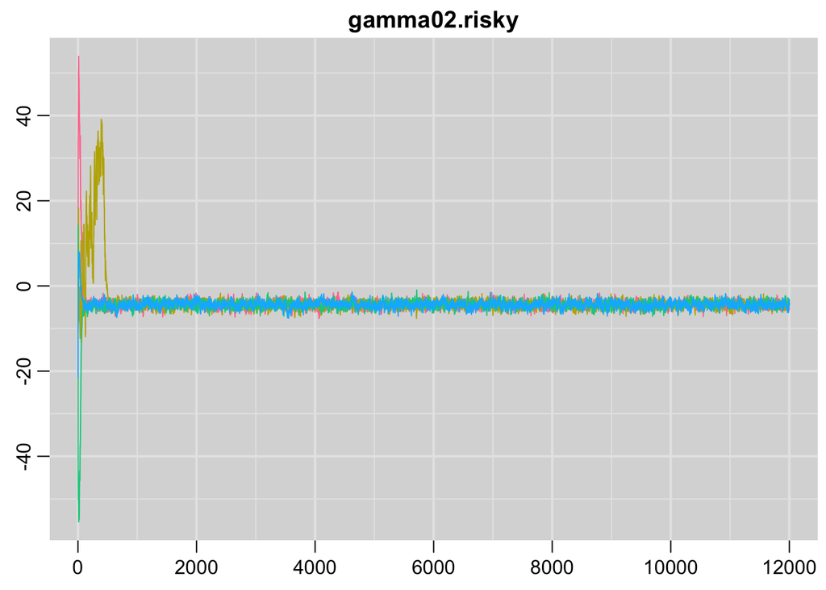

```r
traplot(model03.r2jags, parms = "gamma02.risky")
```

```r
model03a = window(x = as.mcmc(model03.r2jags), start = 2001, end = 12000)
model03a.results = cbind(round(summary(model03a)$statistics, 4), round(summary(model03a)$quantiles, 4), gelman.diag(model03a, multivariate = FALSE)[[1]][,1])

model23comp = cbind(model02a.results[,1:2], model03a.results[,1:2])
model23comp = cbind(model23comp, model23comp[,1] - model23comp[,3])
colnames(model23comp) = c("M2.PosteriorMean","M2.PosteriorSD", "M3.PosteriorMean","M3.PosteriorSD","M2-M3 Mean Dif")
model23comp
```

```
##                 M2.PosteriorMean M2.PosteriorSD M3.PosteriorMean
## G.monitor[1,1]            0.1964         0.0236           0.1966
## G.monitor[2,1]           -0.0008         0.0041          -0.0007
## G.monitor[1,2]           -0.0008         0.0041          -0.0007
## G.monitor[2,2]            0.0108         0.0014           0.0108
## G.risky[1,1]             14.5259         2.0513          14.5069
## G.risky[2,1]              1.5506         0.3597           1.5449
## G.risky[1,2]              1.5506         0.3597           1.5449
## G.risky[2,2]              0.4518         0.0845           0.4508
## deviance               7219.8610        47.2797        7219.3678
## gamma00.monitor           0.0650         0.0342           0.0650
## gamma00.risky            23.6138         0.3387          23.6134
## gamma01.risky            -3.3253         0.5192          -3.3332
## gamma02.risky            -7.9794         0.8931          -4.3937
## gamma03.risky             3.5519         3.5474           3.5259
## gamma10.monitor          -0.0033         0.0083          -0.0033
## gamma10.risky             2.0052         0.1404           2.0065
## gamma11.risky            -0.5286         0.1063          -0.5295
## gamma12.risky            -0.5567         0.1666          -0.5482
## gamma13.risky            -5.2740         0.8405          -1.7146
## gamma20.risky             0.1466         0.0206           0.1468
## gamma30.risky             3.5463         0.3036           3.5454
## sigma2.monitor            0.0813         0.0036           0.0812
## sigma2.risky              7.3520         0.3288           7.3512
##                 M3.PosteriorSD M2-M3 Mean Dif
## G.monitor[1,1]          0.0237        -0.0002
## G.monitor[2,1]          0.0041        -0.0001
## G.monitor[1,2]          0.0041        -0.0001
## G.monitor[2,2]          0.0014         0.0000
## G.risky[1,1]            2.0383         0.0190
## G.risky[2,1]            0.3587         0.0057
## G.risky[1,2]            0.3587         0.0057
## G.risky[2,2]            0.0845         0.0010
## deviance               47.0498         0.4932
## gamma00.monitor         0.0343         0.0000
## gamma00.risky           0.3360         0.0004
## gamma01.risky           0.5196         0.0079
## gamma02.risky           0.8003        -3.5857
## gamma03.risky           3.5603         0.0260
## gamma10.monitor         0.0083         0.0000
## gamma10.risky           0.1401        -0.0013
## gamma11.risky           0.1067         0.0009
## gamma12.risky           0.1656        -0.0085
## gamma13.risky           0.7428        -3.5594
## gamma20.risky           0.0206        -0.0002
## gamma30.risky           0.3005         0.0009
## sigma2.monitor          0.0036         0.0001
## sigma2.risky            0.3291         0.0008
```

Notice the difference in two parameter values…ask Lesa Hoffman why that happens to be.